# Statistical Inference

Naqeeb Asif

4 February 2018

# Probability density functions

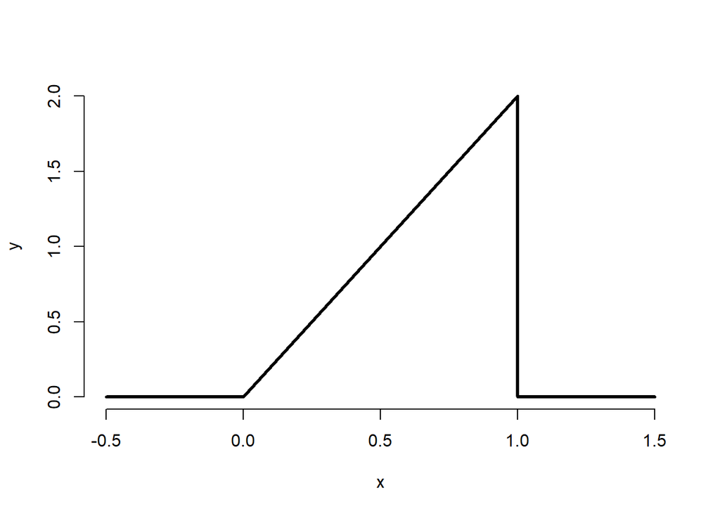

```r
x <- c(-0.5,0,1,1,1.5)
y <- c(0,0,2,0,0)
plot(x,y,lwd=3,frame=FALSE,type="l")
```

## Beta pdf

```r
pbeta(0.75,2,1)
```

```
## [1] 0.5625
```

# Expected Values

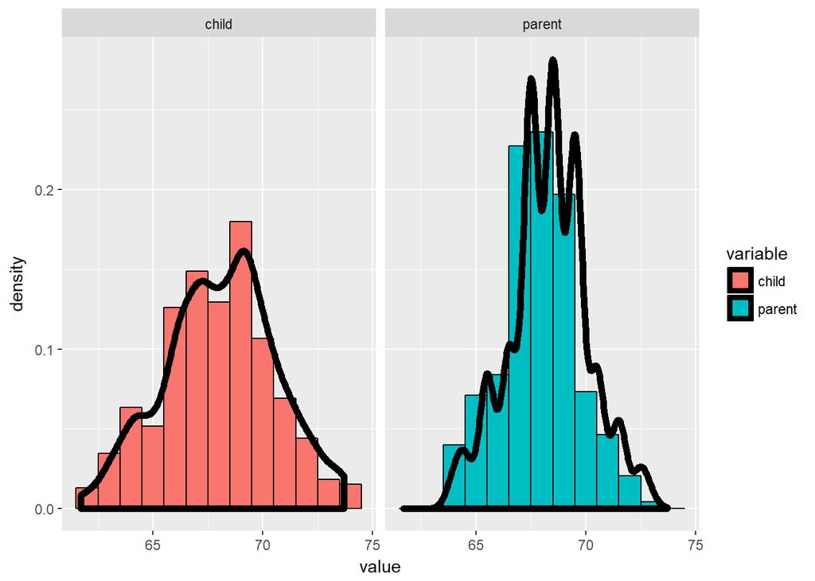

```r
library(UsingR); data(galton); library(ggplot2); library(reshape2)
longGalton <- melt(galton, measure.vars = c("child", "parent"))
g <- ggplot(longGalton, aes(x = value)) + geom_histogram(aes(y = ..density.., fill = variable), binwidth=1, color = "black") + geom_density(size = 2)
g <- g + facet_grid(. ~ variable)
g
```

```r
# library(manipulate)
# myHist <- function(mu){
# g <- ggplot(galton, aes(x = child))
# g <- g + geom_histogram(fill = "salmon",
# binwidth=1, aes(y = ..density..), color = "black")
# g <- g + geom_density(size = 2)
# g <- g + geom_vline(xintercept = mu, size = 2)
# mse <- round(mean((galton$child - mu)^2), 3)
# g <- g + labs(title = paste('mu = ', mu, ' MSE = ', mse))
# g
# }
# manipulate(myHist(mu), mu = slider(62, 74, step = 0.5))
```

# Simulation

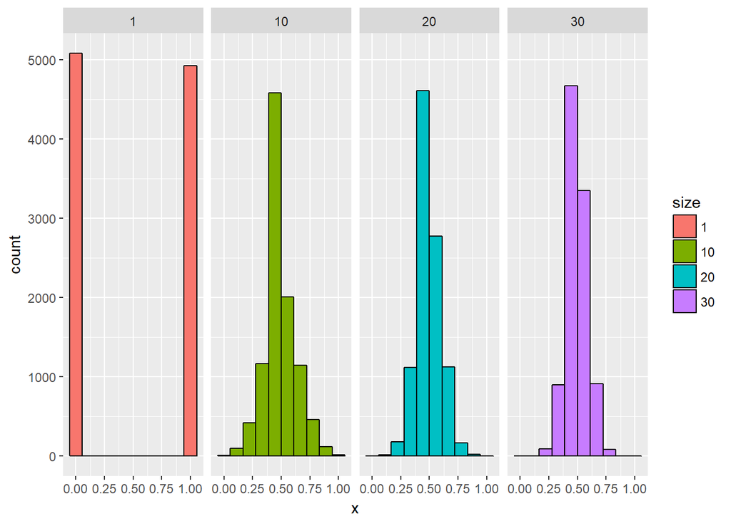

```r
sim_avg_flips=function(n,n_avg_list){
  res <- rep(NA,n*length(n_avg_list))
  i=1
  for(l in 1:length(n_avg_list)){
    while(i<=l*n){
      res[i]=mean(rbinom(n_avg_list[l],1,prob = 0.5))
      i=i+1
    }
  }
  res
}
n=10000
data <- data.frame(size=factor(rep(c(1,10,20,30),each=n)),
                   x=sim_avg_flips(n,c(1,10,20,30)))

g <- ggplot(data=data,aes(x,fill=size))
g+facet_grid(.~size)+geom_histogram(bins = 10,colour=c('black'))
```

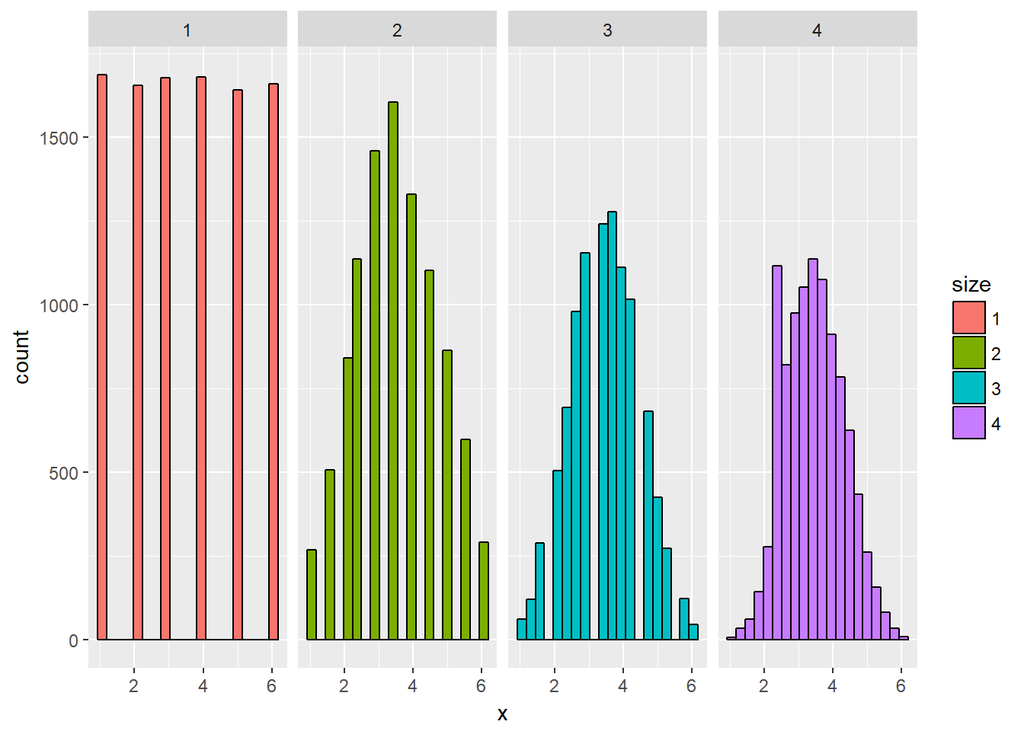

```r
sim_avg_rolls=function(n,n_avg_list){
  res <- numeric()
  for(l in n_avg_list){
    res <- c(res,replicate(n=n,mean(sample(1:6,l,replace = TRUE))))
  }
  res
}
n=10000
data <- data.frame(size=factor(rep(c(1,2,3,4),each=n)),
                   x=sim_avg_rolls(n,c(1,2,3,4)))

g <- ggplot(data=data,aes(x,fill=size))
g+facet_grid(.~size)+geom_histogram(bins = 20,colour=c('black'))
```

# Variation

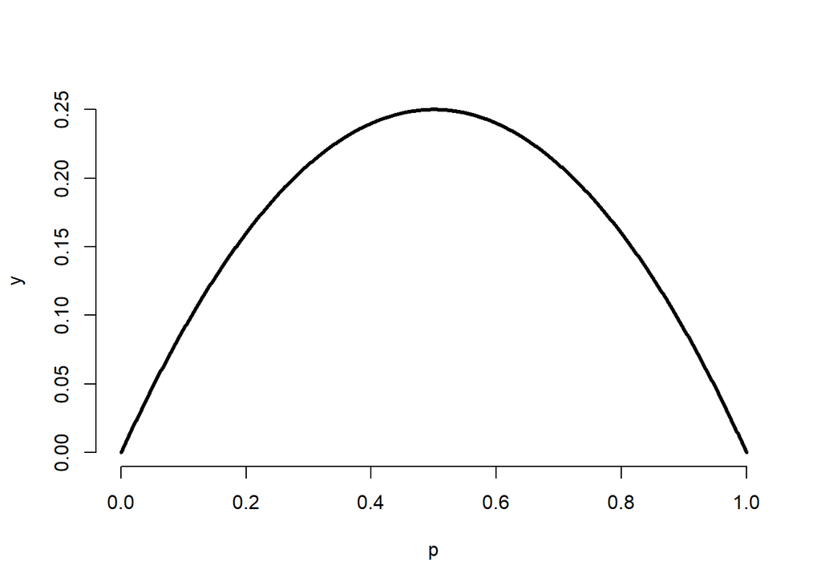

```r
p = seq(0 , 1, length = 1000)
y = p * (1 - p)
plot(p, y, type = "l", lwd = 3, frame = FALSE)
```

## Variance of x die rolls

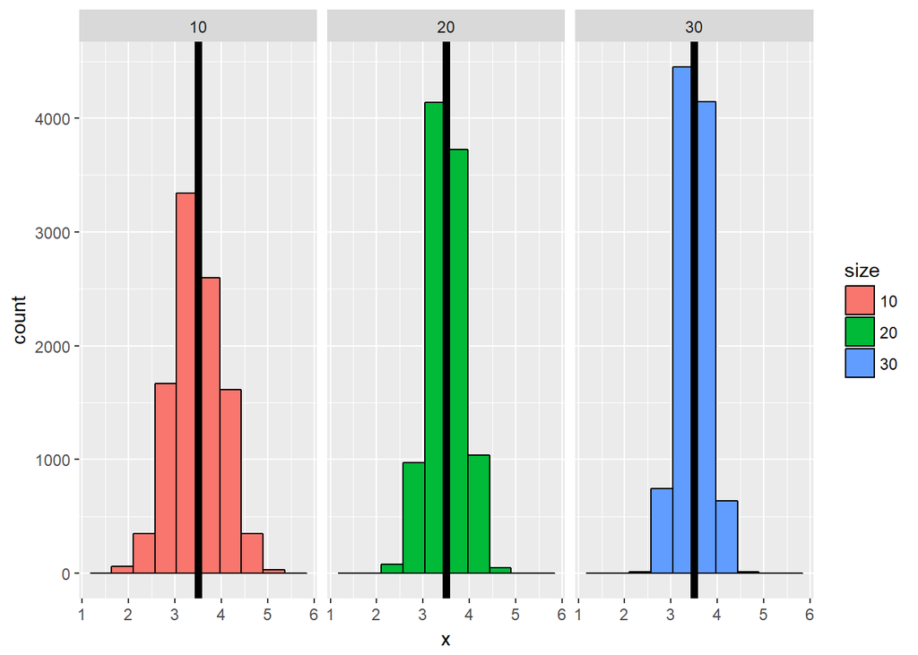

```r
n=10000
data <- data.frame(size=factor(rep(c(10,20,30),each=n)),
                   x=sim_avg_rolls(n,c(10,20,30)))

g <- ggplot(data=data,aes(x,fill=size))
g+facet_grid(.~size)+ geom_histogram(bins = 10,colour=c('black')) +
  geom_vline(aes(xintercept=mean(x)),size=2)
```

# Common Distributions

## Binomila trials

Suppose a friend has 8 children, 7 of which are girls and none are twins. If each gender has an independent 50% probability for each birth, what’s the probability of getting 7 or more girls out of 8 births?

```r
choose(8,7) *0.5^8 + choose(8,8) *0.5^8
```

```
## [1] 0.03515625
```

```r
pbinom(6,size=8,0.5,lower.tail = FALSE)
```

```
## [1] 0.03515625
```

## Normal Distribution

What is the 95th percentile of a N(µ; σ2) distribution?

```r
qnorm(0.95)
```

```
## [1] 1.644854
```

To put some context on our previous setting, population mean BMI for men is reported as² 29 kg/mg2 with a standard deviation of 4.73. Assuming normality of BMI, what is the population 95th percentile?

```r
mu <- 29
v <- 4.73
1.645*v +mu
```

```
## [1] 36.78085
```

```r
qnorm(0.95,mean = 29,sd=4.73)
```

```
## [1] 36.78016
```

Assume that the number of daily ad clicks for a company is (approximately) normally distributed with a mean of 1020 and a standard deviation of 50. What’s the probability of getting more than 1,160 clicks in a day?

```r
pnorm(1160,mean = 1020,sd = 50,lower.tail = FALSE) *100
```

```
## [1] 0.255513
```

Consider the previous example again. What number of daily ad clicks would represent the one where 75% of days have fewer clicks (assuming days are independent and identically distributed)?

```r
qnorm(0.75,mean=1020,sd=50)
```

```
## [1] 1053.724
```

## Poisson Distribution

The number of people that show up at a bus stop is Poisson with a mean of 2.5 per hour. If watching the bus stop for 4 hours, what is the probability that 3 or fewer people show up for the whole time?

```r
ppois(3,2.5*4)
```

```
## [1] 0.01033605
```

### Poisson approximation to the binomial

We flip a coin with success probability 0.01 five hundred times. What’s the probability of 2 or fewer successes?

```r
(choose(500,2)*0.01^2 *(1-0.01)^498) +(choose(500,1)*0.01^1 *(1-0.01)^499)
```

```
## [1] 0.1168153
```

```r
pbinom(2,500,prob = 0.01)
```

```
## [1] 0.1233858
```

```r
ppois(2,lambda = 500*0.01)
```

```
## [1] 0.124652
```

## Exercises

Your friend claims that changing the font to comic sans will result in more ad revenue on your web sites. When presented in random order, 9 pages out of 10 had more revenue when the font was set to comic sans. If it was really a coin flip for these 10 sites, what’s the probability of getting 9 or 10 out of 10 with more revenue for the new font?

```r
pbinom(8,10,lower.tail = F,prob = 0.5)
```

```
## [1] 0.01074219
```

A software company is doing an analysis of documentation errors of their products. They sampled their very large codebase in chunks and found that the number of errors per chunk was approximately normally distributed with a mean of 11 errors and a standard deviation of 2. When randomly selecting a chunk from their codebase, whats the probability of fewer than 5 documentation errors?

```r
pnorm(5,mean = 11,sd=2)
```

```
## [1] 0.001349898
```

The number of search entries entered at a web site is Poisson at a rate of 9 searches per minute. The site is monitored for 5 minutes. What is the probability of 40 or fewer searches in that time frame?

```r
ppois(40,lambda = 9*5)
```

```
## [1] 0.2555451
```

Suppose that the number of web hits to a particular site are approximately normally distributed with a mean of 100 hits per day and a standard deviation of 10 hits per day. What’s the probability that a given day has fewer than 93 hits per day expressed as a percentage to the nearest percentage point?

```r
pnorm(93,mean=100,sd=10)
```

```
## [1] 0.2419637
```

Suppose that the number of web hits to a particular site are approximately normally distributed with a mean of 100 hits per day and a standard deviation of 10 hits per day. What number of web hits per day represents the number so that only 5% of days have more hits? Watch a video solution⁶ and see the problem and solution⁷.

```r
qnorm(0.05,mean=100,sd=10,lower.tail = F)
```

```
## [1] 116.4485
```

Suppose that the number of web hits to a particular site are approximately normally distributed with a mean of 100 hits per day and a standard deviation of 10 hits per day. Imagine taking a random sample of 50 days. What number of web hits would be the point so that only 5% of averages of 50 days of web traffic have more hits? Watch a video solution⁸ and see the problem and solution⁹

```r
qnorm(0.05,mean=100,sd=10/sqrt(50),lower.tail = F)
```

```
## [1] 102.3262
```

You don’t believe that your friend can discern good wine from cheap. Assuming that you’re right, in a blind test where you randomize 6 paired varieties (Merlot, Chianti, …) of cheap and expensive wines. What is the change that she gets 5 or 6 right?

```r
pbinom(4, prob = .5, size = 6, lower.tail = FALSE)
```

```
## [1] 0.109375
```

The number of web hits to a site is Poisson with mean 16.5 per day. What is the probability of getting 20 or fewer in 2 days?

```r
ppois(20,16.5*2)
```

```
## [1] 0.01045391
```

# Asymptopia

## Law of Large Numbers

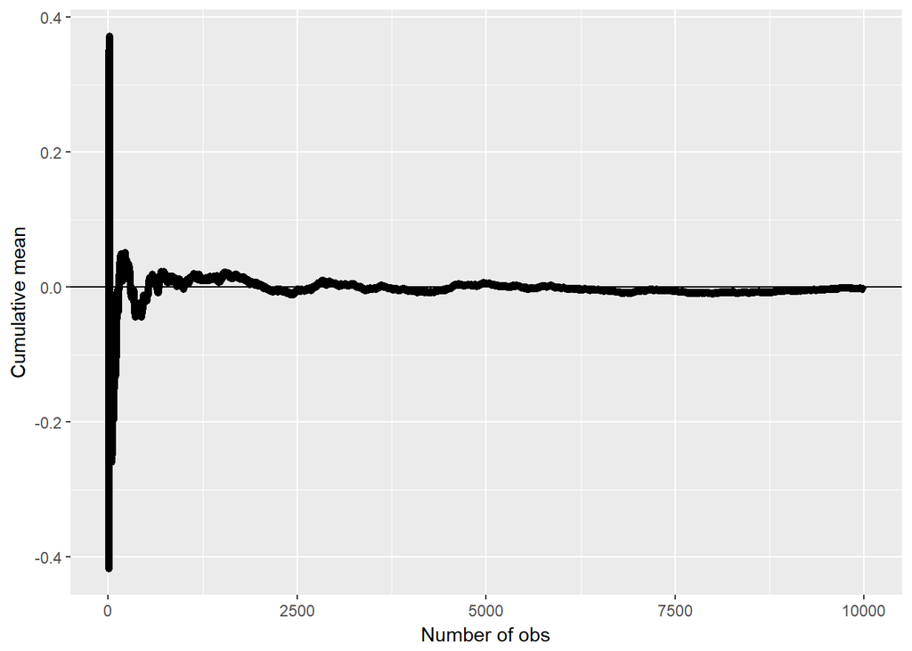

```r
library(ggplot2)

n <- 10000
means <- cumsum(rnorm(n))/(1:n)
library(ggplot2)
g <- ggplot(data.frame(x = 1:n, y = means), aes(x = x, y = y))
g <- g + geom_hline(yintercept = 0) + geom_line(size = 2)
g <- g + labs(x = "Number of obs", y = "Cumulative mean")
g
```